# Lab 6 - Text Mining

Author

Sylwia Lipior

```r
library(readr)
library(dplyr)
mt_samples <- read_csv("https://raw.githubusercontent.com/USCbiostats/data-science-data/master/00_mtsamples/mtsamples.csv")
mt_samples <- mt_samples %>%
  select(description, medical_specialty, transcription)

head(mt_samples)
```

```
# A tibble: 6 × 3
  description                                    medical_specialty transcription
  <chr>                                          <chr>             <chr>
1 A 23-year-old white female presents with comp… Allergy / Immuno… "SUBJECTIVE:…
2 Consult for laparoscopic gastric bypass.       Bariatrics        "PAST MEDICA…
3 Consult for laparoscopic gastric bypass.       Bariatrics        "HISTORY OF …
4 2-D M-Mode. Doppler.                           Cardiovascular /… "2-D M-MODE:…
5 2-D Echocardiogram                             Cardiovascular /… "1.  The lef…
6 Morbid obesity.  Laparoscopic antecolic anteg… Bariatrics        "PREOPERATIV…
```

## **Question 1: What specialties do we have?**

```r
mt_samples %>%
  count(medical_specialty, sort = TRUE)
```

```
# A tibble: 40 × 2
   medical_specialty                 n
   <chr>                         <int>
 1 Surgery                        1103
 2 Consult - History and Phy.      516
 3 Cardiovascular / Pulmonary      372
 4 Orthopedic                      355
 5 Radiology                       273
 6 General Medicine                259
 7 Gastroenterology                230
 8 Neurology                       223
 9 SOAP / Chart / Progress Notes   166
10 Obstetrics / Gynecology         160
# ℹ 30 more rows
```

## **Question 2**

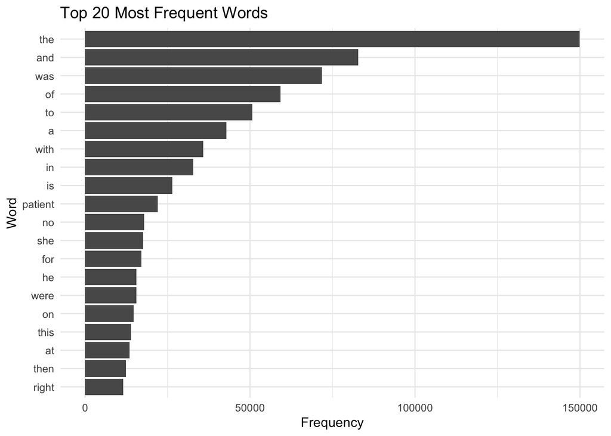

```r
# Load required libraries
library(tidytext)
library(dplyr)
library(ggplot2)

# Tokenize words and count frequencies
word_counts <- mt_samples %>%
  unnest_tokens(word, transcription) %>%
  count(word, sort = TRUE)

# Visualize the top 20 most frequent words
top_words <- head(word_counts, 20)

# Create a bar plot
ggplot(top_words, aes(x = reorder(word, n), y = n)) +
  geom_bar(stat = "identity") +
  labs(title = "Top 20 Most Frequent Words", x = "Word", y = "Frequency") +
  coord_flip() +
  theme_minimal()
```

Interpretation: These are very common words in the English language and may not provide specific insights into the content of the transcriptions. Therefore, we need to be more specific if we want to make any meaningful insights about word frequency.

## Question 3

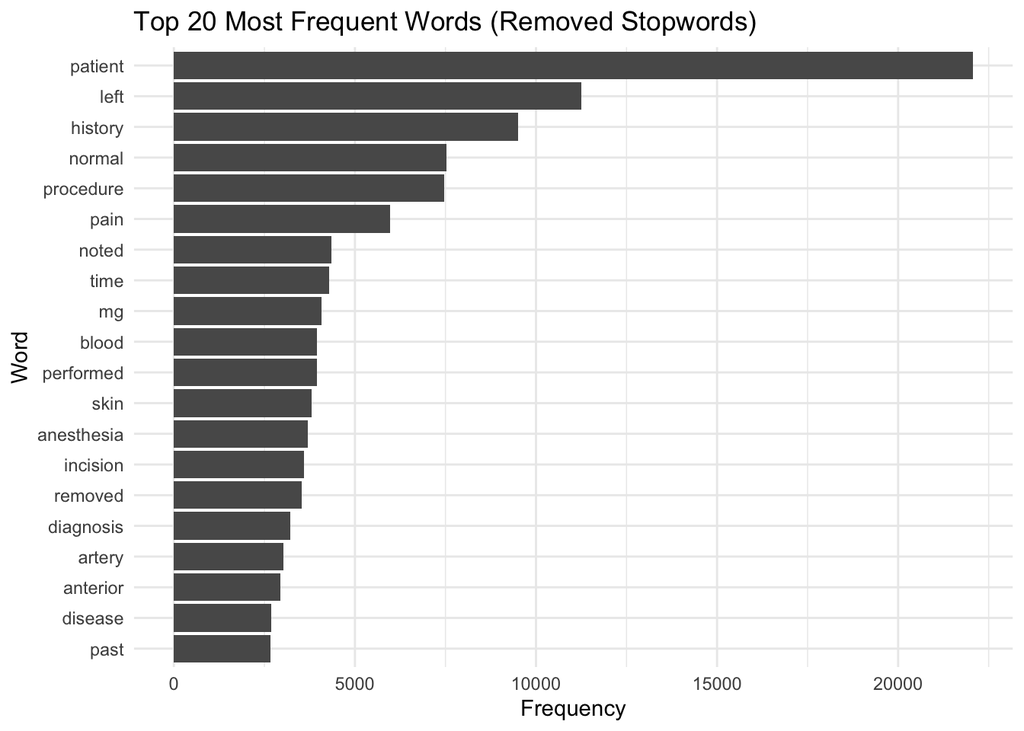

```r
library(stringr)
library(tidytext)
library(dplyr)
library(ggplot2)

# Remove stopwords and numbers
mt_samples_cleaned <- mt_samples %>%
  unnest_tokens(word, transcription) %>%
  anti_join(stop_words) %>%
  filter(!str_detect(word, "\\d+"))
# Count the number of times each token appears
word_counts <- mt_samples_cleaned %>%
  count(word, sort = TRUE)

# Visualize the top 20 most frequent words
top_words <- word_counts %>%
  slice_max(n = 20, order_by = n)

# Assuming you have 'top_words' data frame with word frequencies

ggplot(top_words, aes(x = reorder(word, n), y = n)) +
  geom_bar(stat = "identity") +
  labs(title = "Top 20 Most Frequent Words (Removed Stopwords)", x = "Word", y = "Frequency") +
  coord_flip() +
  theme_minimal()
```

## Question 4

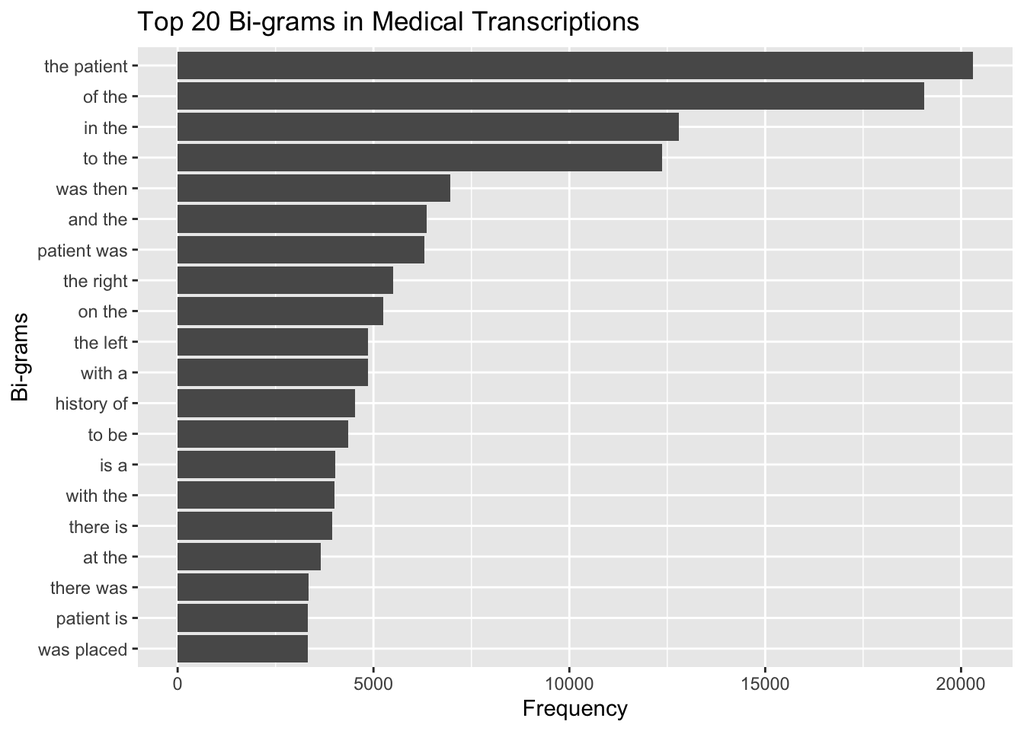

```r
library(tidytext)

# Tokenizing into bi-grams
bigrams <- mt_samples %>%
  unnest_ngrams(ngram, transcription, n = 2)  # 2 for bi-grams

# Counting the number of times each bi-gram appears
bigram_counts <- bigrams %>%
  count(ngram, sort = TRUE)

# Visualizing top 20 bi-grams
library(ggplot2)

ggplot(bigram_counts[1:20,], aes(x = reorder(ngram, n), y = n)) +
  geom_bar(stat = "identity") +
  coord_flip() +
  labs(title = "Top 20 Bi-grams in Medical Transcriptions",
       x = "Bi-grams", y = "Frequency")
```

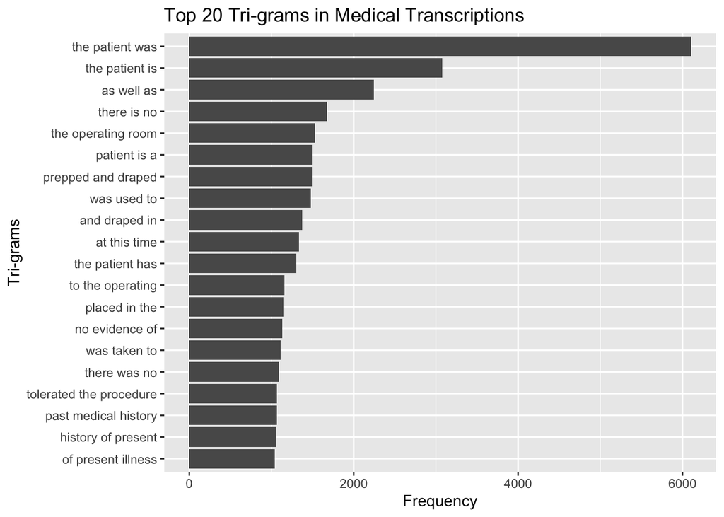

```r
# Tokenizing into tri-grams
trigrams <- mt_samples %>%
  unnest_ngrams(ngram, transcription, n = 3)  # 3 for tri-grams

# Counting the number of times each tri-gram appears
trigram_counts <- trigrams %>%
  count(ngram, sort = TRUE)

# Visualizing top 20 tri-grams
ggplot(trigram_counts[1:20,], aes(x = reorder(ngram, n), y = n)) +
  geom_bar(stat = "identity") +
  coord_flip() +
  labs(title = "Top 20 Tri-grams in Medical Transcriptions",
       x = "Tri-grams", y = "Frequency")
```

Interpretation: The common bi-grams add a little more meaning, but since the second word is commonly a stopword/transcription word, there is a lot more meaning in the most frequent tri-grams. You start to get pretty close to meaningful phrases once you have tri-grams, and as expected, the phrases have a lot to do with patients, operations, medical history, and illness, since we are specifically looking at medical data.

## Question 5: Extract words before and after “patient”

```r
library(tidytext)
library(dplyr)

# Extracting bigrams with "patient"
patient_bigrams <- bigrams %>%
  filter(grepl("patient", ngram))

# Splitting the bigrams to extract words before and after "patient"
words_around_patient <- patient_bigrams %>%
  mutate(before_patient = ifelse(grepl("^\\w+ patient$", ngram), str_extract(ngram, "^\\w+"), NA),
         after_patient = ifelse(grepl("^patient \\w+$", ngram), str_extract(ngram, "\\w+$"), NA))

words_before_patient <- words_around_patient %>%
  filter(!is.na(before_patient)) %>%
  count(before_patient, sort = TRUE)

head(words_before_patient)
```

```
# A tibble: 6 × 2
  before_patient     n
  <chr>          <int>
1 the            20307
2 this             470
3 history          101
4 a                 67
5 and               47
6 procedure         32
```

```r
words_after_patient <- words_around_patient %>%
  filter(!is.na(after_patient)) %>%
  count(after_patient, sort = TRUE)

head(words_after_patient)
```

```
# A tibble: 6 × 2
  after_patient     n
  <chr>         <int>
1 was            6293
2 is             3332
3 has            1417
4 tolerated       994
5 had             888
6 will            616
```

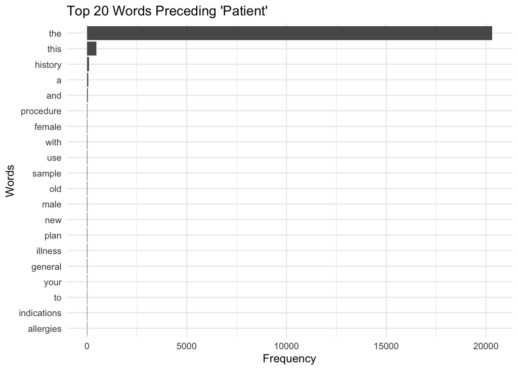

```r
# Top 20 words preceding "patient"
ggplot(words_before_patient[1:20,], aes(x = reorder(before_patient, n), y = n)) +
  geom_bar(stat = "identity") +
  coord_flip() +
  labs(title = "Top 20 Words Preceding 'Patient'",
       x = "Words", y = "Frequency") +
  theme_minimal()
```

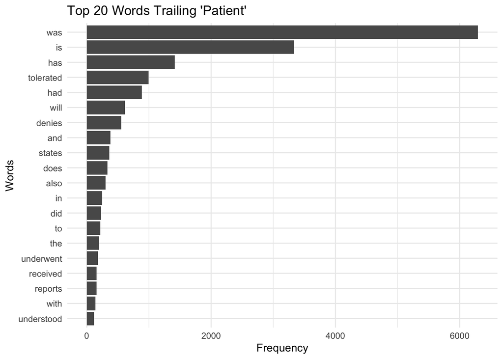

```r
# Top 20 words trailing "patient"
ggplot(words_after_patient[1:20,], aes(x = reorder(after_patient, n), y = n)) +
  geom_bar(stat = "identity") +
  coord_flip() +
  labs(title = "Top 20 Words Trailing 'Patient'",
       x = "Words", y = "Frequency") +
  theme_minimal()
```

Interpretation: It makes sense that the word most often preceding patient is the word “the”. It’s interesting that it seems that patient most often starts sentences, since there aren’t many words that precede patient. It also makes sense that words like “was,” “is,” “has,” and “tolerated” are the most frequency words that trail patient, in the context of medical records.

## Question 6: Let’s look at the top 5 words by medical specialty

```r
library(tidytext)
library(dplyr)
library(tidyr)

# Tokenizing words and removing stopwords
word_counts <- mt_samples %>%
  unnest_tokens(word, transcription) %>%
  anti_join(stop_words) %>%
  filter(!str_detect(word, "^[0-9]+$")) %>%
  group_by(medical_specialty) %>%
  count(word, sort = TRUE)
# Extracting the top 3 words for each specialty and reshaping the data
top_words_per_specialty <- word_counts %>%
  group_by(medical_specialty) %>%
  slice_head(n = 5) %>%
  mutate(rank = row_number()) %>%
  pivot_wider(
    names_from = rank,
    values_from = c(word, n),
    names_glue = "{.value}{.name}"
  )

# Rename columns
names(top_words_per_specialty) <- gsub("wordword", "word", names(top_words_per_specialty))
names(top_words_per_specialty) <- gsub("nn", "n", names(top_words_per_specialty))

# Viewing the result
top_words_per_specialty
```

```
# A tibble: 40 × 11
# Groups:   medical_specialty [40]
   medical_specialty  word_1 word_2 word_3 word_4 word_5   n_1   n_2   n_3   n_4
   <chr>              <chr>  <chr>  <chr>  <chr>  <chr>  <int> <int> <int> <int>
 1 Allergy / Immunol… histo… noted  patie… aller… nasal     38    23    22    21
 2 Autopsy            left   inch   neck   anter… body      83    59    55    47
 3 Bariatrics         patie… histo… weight surge… gastr…    62    50    36    34
 4 Cardiovascular / … left   patie… artery coron… histo…  1550  1516  1085   681
 5 Chiropractic       pain   patie… dr     histo… left     187    85    66    56
 6 Consult - History… patie… histo… normal pain   mg      3046  2820  1368  1153
 7 Cosmetic / Plasti… patie… proce… breast skin   incis…   116    98    95    88
 8 Dentistry          patie… tooth  teeth  left   proce…   195   108   104    94
 9 Dermatology        patie… skin   cm     left   proce…   101   101    77    58
10 Diets and Nutriti… patie… weight carbo… day    food      43    40    37    28
# ℹ 30 more rows
# ℹ 1 more variable: n_5 <int>
```

Interpretation: The most common words vary by medical specialty, but most of them share the word patient in the top 5. It’s interesting that in dermatology, the most common words after patient are skin and cm. In Diets, the most common words are weight and carbohydrate. Neurosurgery’s most used words include c5 and c6. Therefore, as expected, the most common words are specialty specific words.

## Question 7

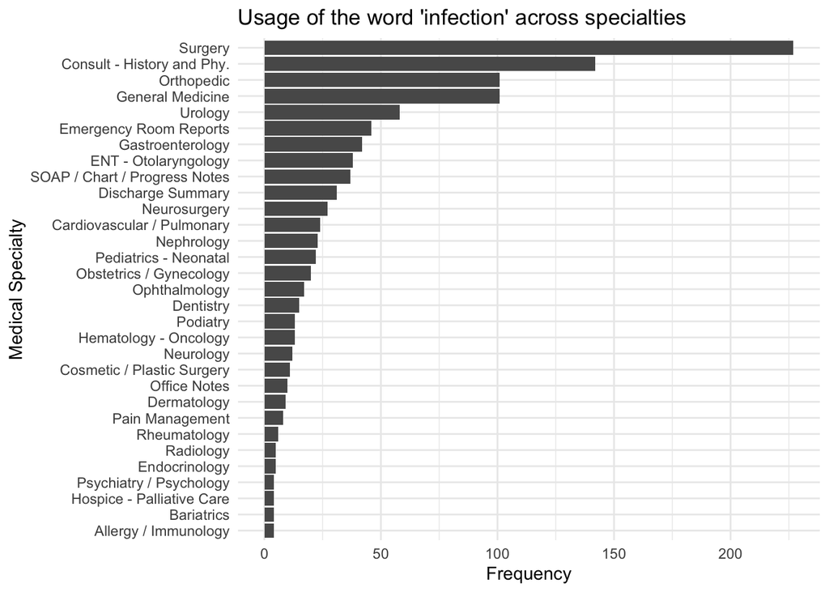

```r
word_usage <- mt_samples %>%
  unnest_tokens(word, transcription) %>%
  filter(word == "infection") %>%
  count(medical_specialty, sort = TRUE)

# Visualizing word usage across specialties
ggplot(word_usage, aes(x = reorder(medical_specialty, n), y = n)) +
  geom_col() +
  coord_flip() +
  labs(title = "Usage of the word 'infection' across specialties", x = "Medical Specialty", y = "Frequency") +
  theme_minimal()
```

Interpretation: Infection is a medically relevant word, so I decided to look at it’s frequency across specialties. It’s interesting the infection is most commonly used in surgery, consult, and orthopedic and least commonly used in hospice, bariatrics, and allergy/immunology.